# 10_graph_inverse

## 10_graph_inverse

#### Question

1. The [one-to-one](https://en.wikipedia.org/wiki/Injective_function) function $f$ is plotted below:

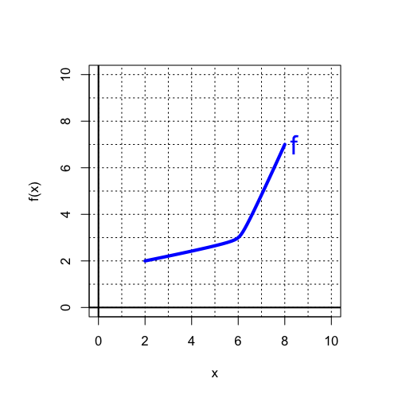

   Which of the following red curves is a graph of the inverse function, $f^{-1}$?
   - A

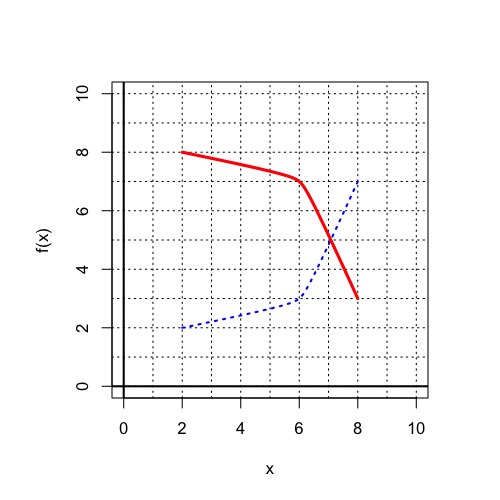

   - B

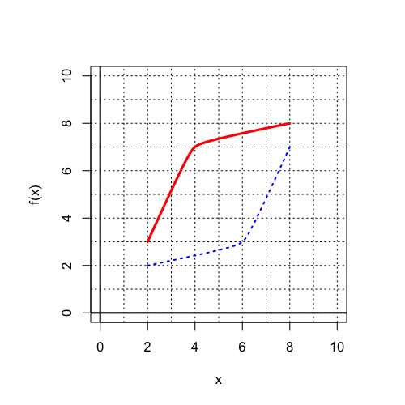

   - C

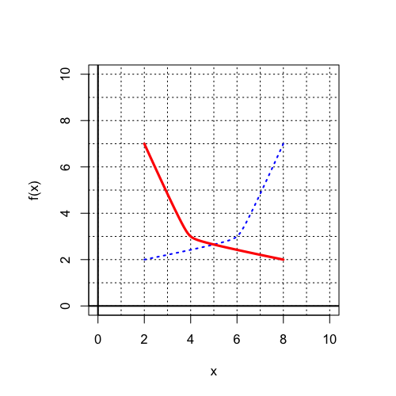

   - D

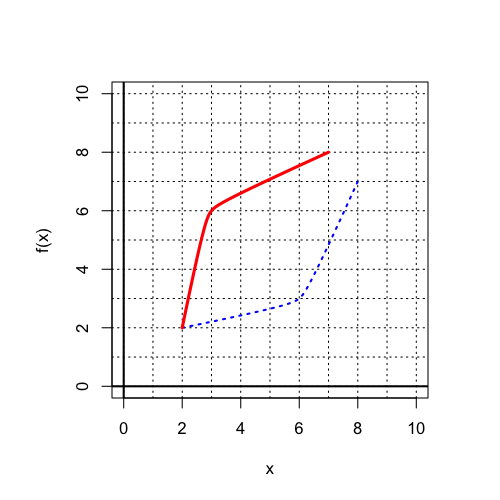

   1. A
   2. B
   3. C
   4. D

#### Question

2. The [one-to-one](https://en.wikipedia.org/wiki/Injective_function) function $f$ is plotted below:

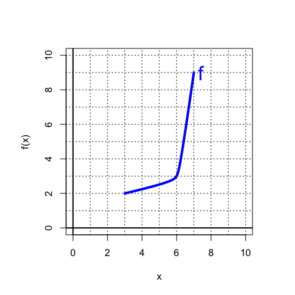

   Which of the following red curves is a graph of the inverse function, $f^{-1}$?
   - A

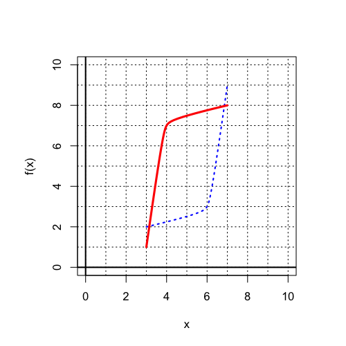

   - B

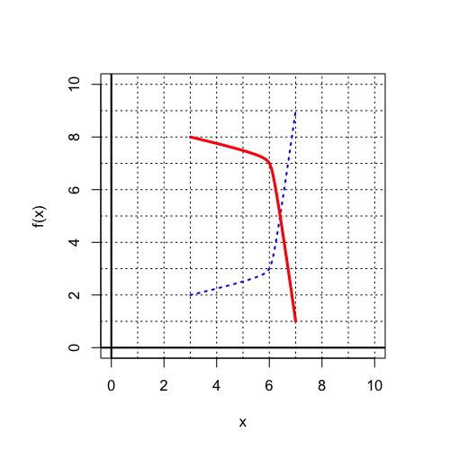

   - C

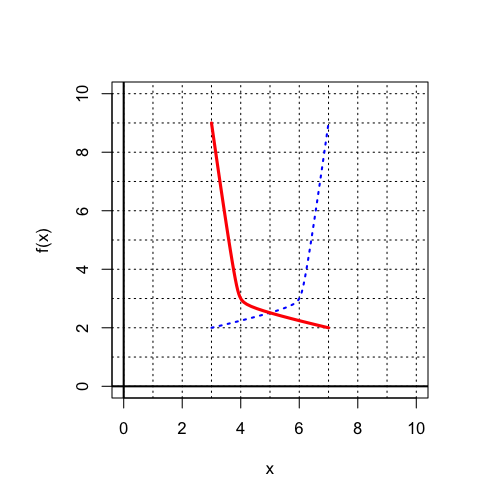

   - D

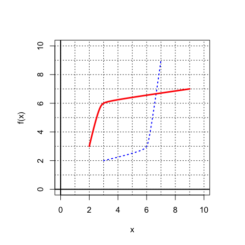

   1. A
   2. B
   3. C
   4. D

#### Question

3. The [one-to-one](https://en.wikipedia.org/wiki/Injective_function) function $f$ is plotted below:

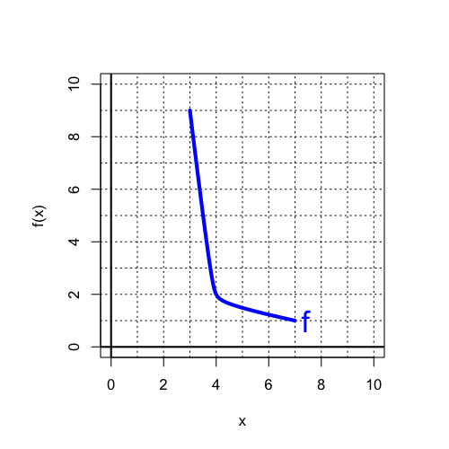

   Which of the following red curves is a graph of the inverse function, $f^{-1}$?
   - A

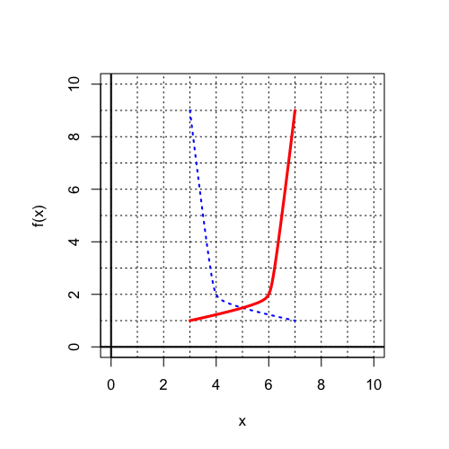

   - B

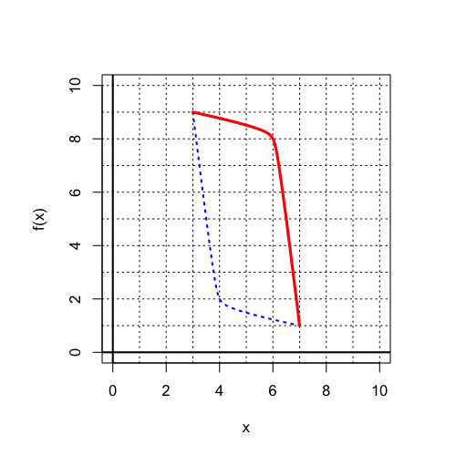

   - C

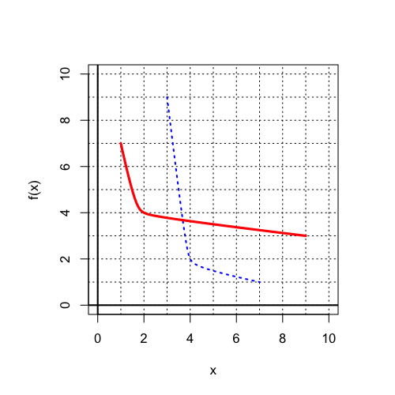

   - D

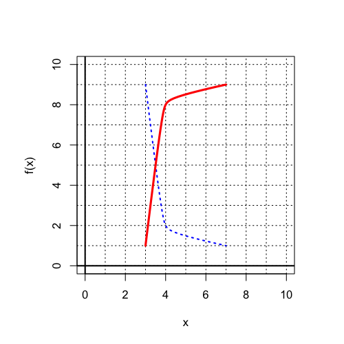

   1. A
   2. B
   3. C
   4. D

#### Question

4. The [one-to-one](https://en.wikipedia.org/wiki/Injective_function) function $f$ is plotted below:

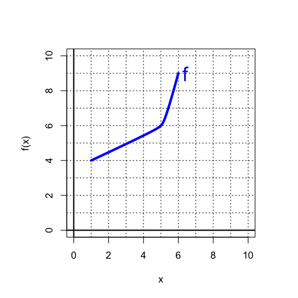

   Which of the following red curves is a graph of the inverse function, $f^{-1}$?
   - A

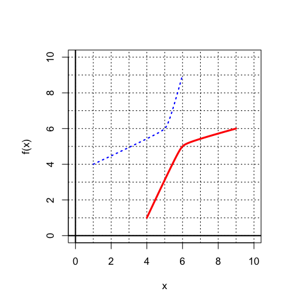

   - B

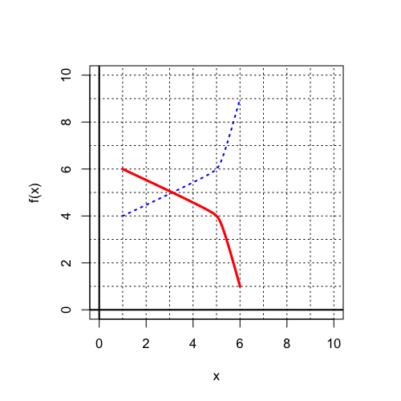

   - C

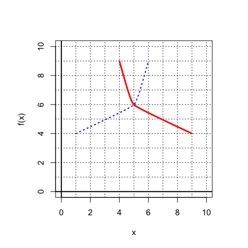

   - D

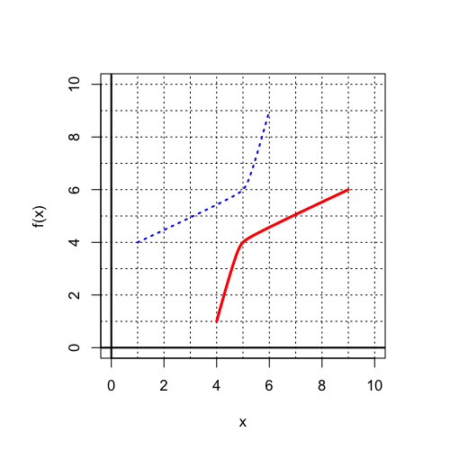

   1. A
   2. B
   3. C
   4. D

#### Question

5. The [one-to-one](https://en.wikipedia.org/wiki/Injective_function) function $f$ is plotted below:

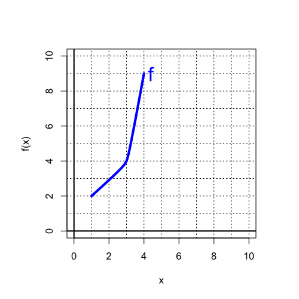

   Which of the following red curves is a graph of the inverse function, $f^{-1}$?
   - A

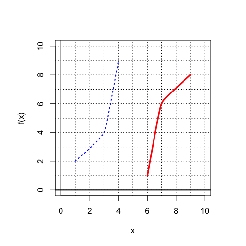

   - B

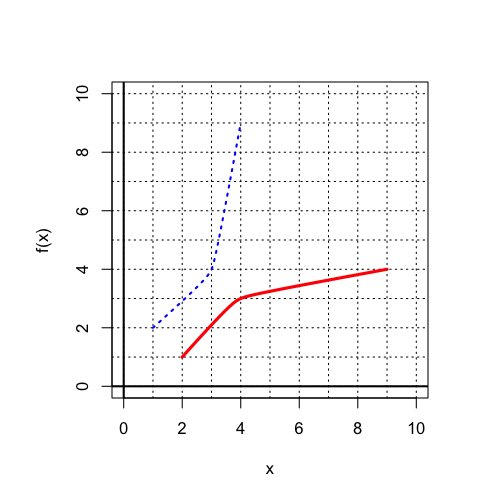

   - C

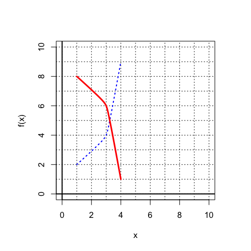

   - D

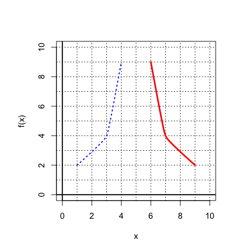

   1. A
   2. B
   3. C
   4. D

#### Question

6. The [one-to-one](https://en.wikipedia.org/wiki/Injective_function) function $f$ is plotted below:

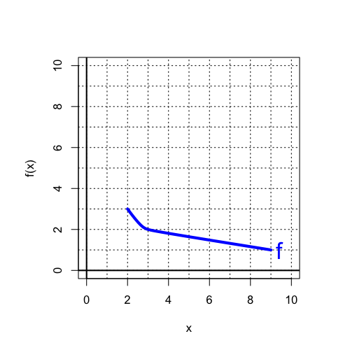

   Which of the following red curves is a graph of the inverse function, $f^{-1}$?
   - A

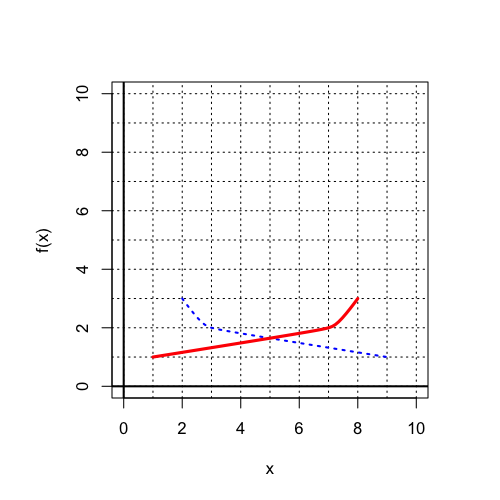

   - B

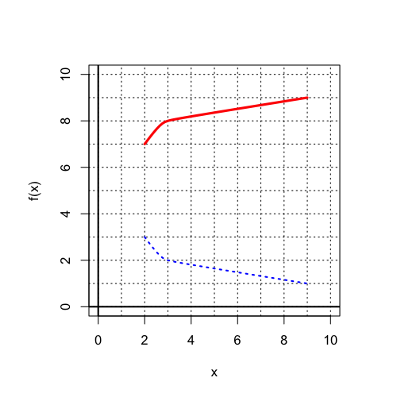

   - C

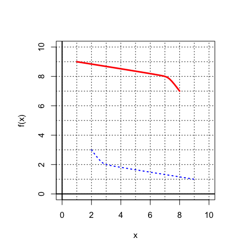

   - D

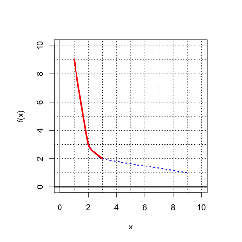

   1. A
   2. B
   3. C
   4. D